# Descriptivas

### Datos cruzados cuadrantes y variables de interés

Para corroborar y ver con más detalle la relación entre los cuadrantes con las variables de interés dicotómicas (indicadores de carencias y accesos), generamos gráficos de barras mostrando al porcentaje de personas que sí o que no contaban con el atributo respectivo. Omitimos las gráficas de los indicadores de carencia por acceso a alimentación, a servicios de combustible, servicios básicos de vivienda y a servicios de salud; y a la carencia por rezago educativo debido a que el porcentaje de personas del cuadrante 3 con estas carencias era 0%.

```
## Plotted dataset d variables s_salud by cuadrantes
```

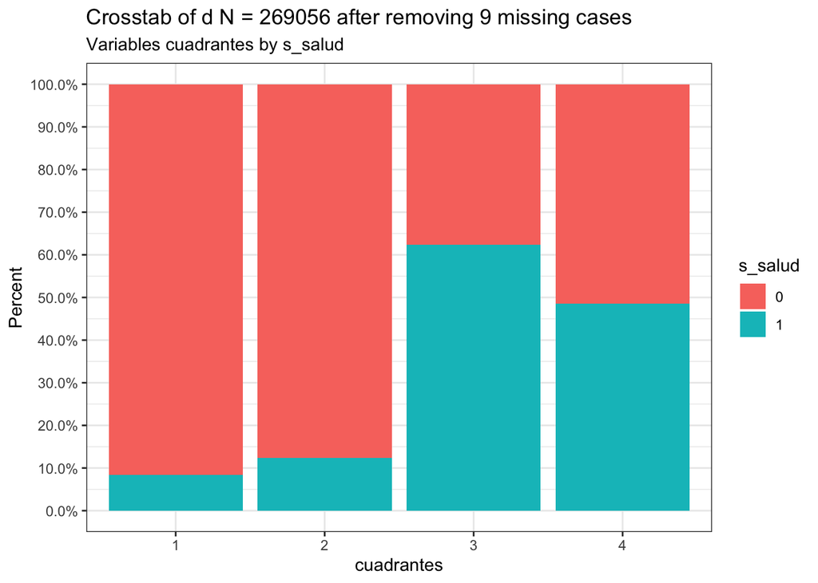

```r
PlotXTabs(d,s_salud,cuadrantes,plottype = "percent")
```

```
## Plotted dataset d variables jef_ss by cuadrantes
```

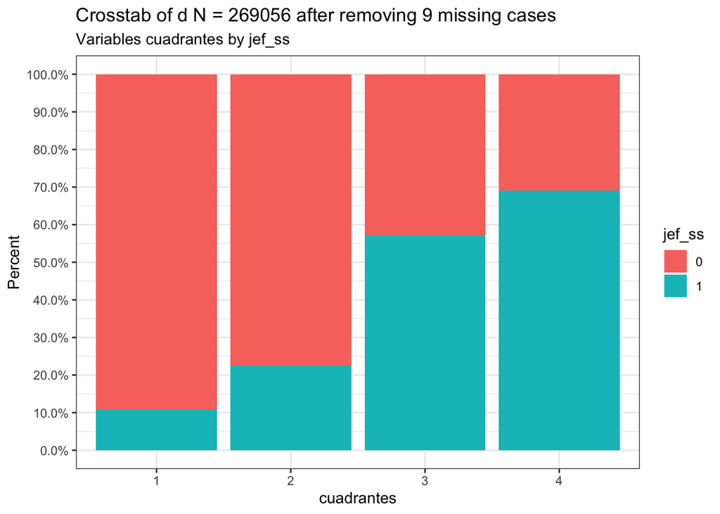

```r
PlotXTabs(d,jef_ss,cuadrantes,plottype = "percent")
```

```
## Plotted dataset d variables ss_dir by cuadrantes
```

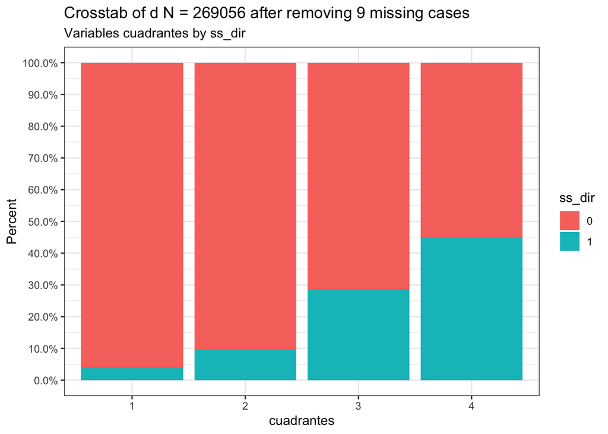

```r
PlotXTabs(d,ss_dir,cuadrantes,plottype = "percent")
```

```
## Plotted dataset d variables rururb by cuadrantes
```

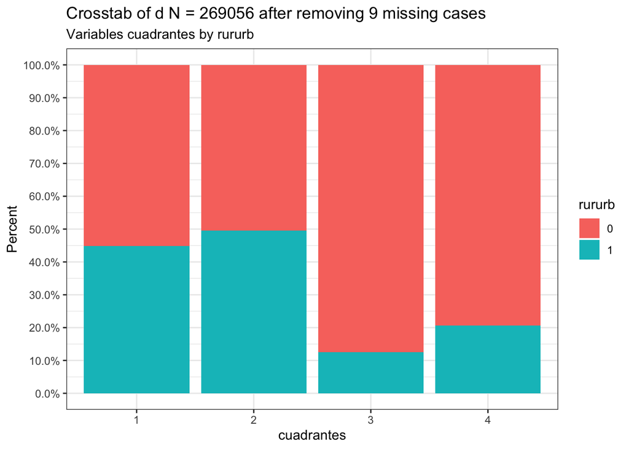

```r
PlotXTabs(d,rururb,cuadrantes,plottype = "percent")
```

```
## Plotted dataset d variables tam_loc by cuadrantes
```

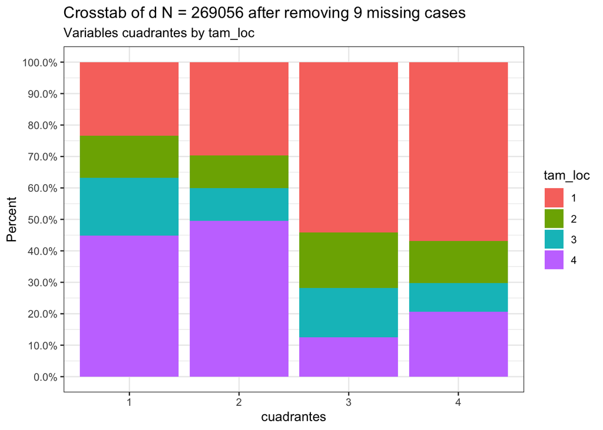

```r
PlotXTabs(d,tam_loc,cuadrantes,plottype = "percent")
```